# Explore OHI Global Data & Data Gaps for Philippines

## Objectives

To explore the OHI Global data for Philippines, focusing on where data are estimated (gapfilled) instead of available in global data sets for Philippines.

## Gapfilling in Philippines

Let’s look a bit deeper to see numerically the percent gapfilling by goal to help us prioritize which goals we want to explore more deeply. We can pull directly from the data from the [Frazier et al. 2015](http://journals.plos.org/plosone/article?id=10.1371/journal.pone.0160377) publication.

It’s interesting to compare the percent gapfilling by goal to the scores by goal. Let’s look at this figure and discuss what we see.

### Figure: % Gapfilled vs. Status Scores

There may be a few places where there are overlaps because goals have the exact same scores.

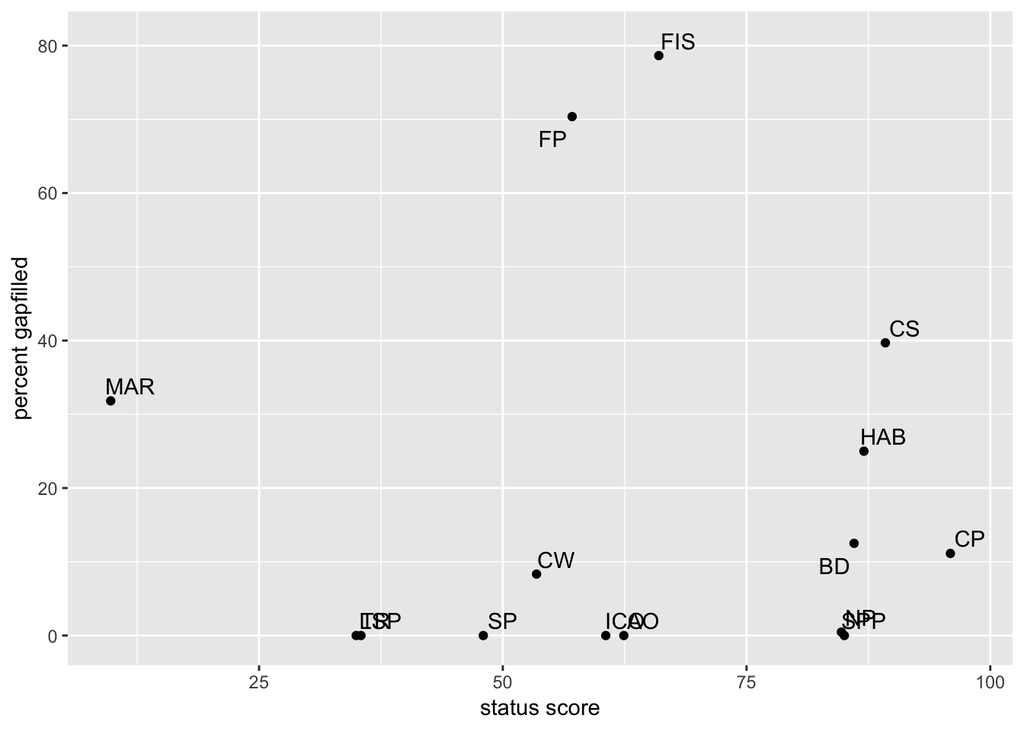

## Gapfilling Observations

Let’s brainstorm together: let’s list overall observations and observations by goal. Then we will prioritize which to dive deeply into and look at the underlying data with the time we have.

### Overall

**Observations:**

### Food Provision (FP)

**Observations**:

### Tourism and Recreation (TR)

### Species-based goals (ICO, SPP)

### Livelihoods and Economies (LE, LIV, ECO)

**Observations**:

- The LE goal is not on the figure. We didn’t include them in our gapfilling analyses because our models rely on old data (pre-2012).

Now, where should we start? What order should we discuss these?

## Data discussion: deep dive

Let’s look into the data behind some of these goals.

We will use several resources for each goal, all linked from [ohi-science.org/ohi-global](http://ohi-science.org/ohi-global%5D):

- ohi-science.org/ohi-global/goals
- [ohi-science.org/ohi-global/layers_table](http://ohi-science.org/ohi-global/layers_table.html)
- [Global supplemental information](https://rawgit.com/OHI-Science/ohi-global/draft/global_supplement/Supplement.html)

## [Food Provision: Fisheries](http://ohi-science.org/ohi-global/goals.html#food_provision:_fisheries)

**Questions:**

- Which species are included in the FIS calculation? Where do the data come from?

#### Global Data

Global data are from the [**Sea Around Us Project**](http://www.seaaroundus.org), which does spatial allocation modeling of FAO catch. Many species do not have formal stock assessments, but they do have tons of catch through time. The criteria we use for our fisheries model is data that has:

- **catch by species**: only what is fished within Philippines’s EEZ
- **years**: at least 10 years of data (preferably 20)

We can look at these data in several ways. Let’s start by looking on SAUP’s website at an interactive visualization of fish caught in Philippines’s exclusive economic zone (EEZ). Here’s how:

1. Navigate to seaaroundus.org
2. Click “Tools & Data”
3. Search “Philippines”

We can also look at the mapped locations of fishing effort by Philippines (remember that OHI only includes catch caught withing Philippines’s EEZ.

1. Click “Mapped Data”

Let’s look through the species listed and see if there are any included that don’t represent Philippines’s fisheries within the EEZ.

#### Mean catch

The mean catch layer ([fis_meancatch](https://github.com/OHI-Science/phl/blob/master/global_explore/data/fis_meancatch_lookup.csv)) is in some ways a historic list because it includes species that may not be caught any more (i.e. was fished in the past and stopped for some reason). It is calculated as the average (mean) of each species’ catch through time, so if it was a big catch in the past but now is 0, it will still average (it keeps all species in the dataset).

It will be more useful for us to look at the raw catch values, and see if any of them don’t seem right. Below the scientific name is listed, with the common name (if known).

|  | stock_name | common |
| --- | --- | --- |
| 1 | Scombroids |  |
| 2 | Sharks_rays_chimaeras |  |
| 3 | Marine_fishes_not_identified |  |
| 4 | Miscellaneous_marine_crustaceans |  |
| 5 | Miscellaneous_marine_molluscs |  |
| 6 | Shrimps_prawns |  |
| 7 | Echinoidea |  |
| 8 | Rajiformes |  |
| 9 | Clupeiformes |  |
| 10 | Gadiformes |  |

[output cut: 262 more lines]

There are 272 species in the [fis_meancatch](https://github.com/OHI-Science/phl/blob/master/global_explore/data/fis_meancatch_lookup.csv) layer for Philippines.

#### Raw catch data

To understand mean catch, dive into catch by species.

Let’s do two things. First, look through the list of species to see if any of them should be removed.

There are 289 unique species.

Do we want to look at the timeseries for any species? For example:

|  | year | taxon_scientific_name | taxon_common_name | tons | stock_id |
| --- | --- | --- | --- | --- | --- |
| 1 | 2014 | Acanthuridae | Surgeons, tangs, unicornfishes | 2036.97368481185 | Acanthuridae-71 |
| 2 | 2013 | Acanthuridae | Surgeons, tangs, unicornfishes | 2119.24919679268 | Acanthuridae-71 |
| 3 | 2012 | Acanthuridae | Surgeons, tangs, unicornfishes | 2148.55102971171 | Acanthuridae-71 |
| 4 | 2011 | Acanthuridae | Surgeons, tangs, unicornfishes | 2173.86809909041 | Acanthuridae-71 |
| 5 | 2010 | Acanthuridae | Surgeons, tangs, unicornfishes | 2168.60226530988 | Acanthuridae-71 |
| 6 | 2009 | Acanthuridae | Surgeons, tangs, unicornfishes | 2114.36429771617 | Acanthuridae-71 |
| 7 | 2008 | Acanthuridae | Surgeons, tangs, unicornfishes | 2092.25060472457 | Acanthuridae-71 |
| 8 | 2007 | Acanthuridae | Surgeons, tangs, unicornfishes | 2071.57941548321 | Acanthuridae-71 |
| 9 | 2006 | Acanthuridae | Surgeons, tangs, unicornfishes | 1800.42722253045 | Acanthuridae-71 |
| 10 | 2005 | Acanthuridae | Surgeons, tangs, unicornfishes | 2014.84939017762 | Acanthuridae-71 |

[output cut: 55 more lines]

#### B/Bmsy

These are the species stocks that we have data for [fis_b_bmsy](https://github.com/OHI-Science/phl/blob/master/global_explore/data/fis_b_bmsy_lookup.csv):

|  | stock_name | common |
| --- | --- | --- |
| 1 | Coryphaena_hippurus | Common dolphinfish |
| 2 | Istiophorus_platypterus | Indo-Pacific sailfish |
| 3 | Euthynnus_affinis | Kawakawa |
| 4 | Katsuwonus_pelamis | Skipjack tuna |
| 5 | Rastrelliger_brachysoma | Short mackerel |
| 6 | Scomber_japonicus | Chub mackerel |
| 7 | Scomberomorus_commerson | Narrowbarred Spanish mackerel |
| 8 | Thunnus_alalunga | Albacore |
| 9 | Thunnus_albacares | Yellowfin tuna |
| 10 | Thunnus_obesus | Bigeye tuna |

[output cut: 42 more lines]

There are only 52 species in the [fis_b_bmsy](https://github.com/OHI-Science/phl/blob/master/global_explore/data/fis_b_bmsy_lookup.csv) layer for Philippines.

Let’s look at these too. Are there any species that don’t seem right?

#### Discussion

- Are there any species that don’t seem right and we should remove, for meancatch or B/Bmsy?
- There are many categories that we only have information at the genus or family levels. Do you have information for species level?

## [Food Provision: Mariculture](http://ohi-science.org/ohi-global/goals.html#food_provision:_mariculture)

**Questions:**

- How do we interpret the MAR score?

### Global Data

#### Tonnes of Harvest

Let’s look at the list of species that are represented in the MAR model as tonnes of harvest: (the [mar_harvest_tonnes](https://github.com/OHI-Science/phl/blob/master/eez/layers/mar_harvest_tonnes.csv) layer).

|  | taxa |
| --- | --- |
| 1 | Banana prawn |
| 2 | Barramundi(=Giant seaperch) |
| 3 | Caulerpa seaweeds |
| 4 | Cupped oysters nei |
| 5 | Flathead lobster |
| 6 | Giant tiger prawn |
| 7 | Green mussel |
| 8 | Groupers, seabasses nei |
| 9 | Indo-Pacific swamp crab |
| 10 | Jacks, crevalles nei |

[output cut: 7 more lines]

Let’s have a peek at the data:

|  | taxa_code | year_min | year_max | total_tonnes | mean_tonnes |
| --- | --- | --- | --- | --- | --- |
| 1 | Banana prawn_72 | 1973 | 2016 | 55045 | 1251.02272727273 |
| 2 | Barramundi(=Giant seaperch)_73 | 1990 | 2016 | 5530 | 204.814814814815 |
| 3 | Caulerpa seaweeds_74 | 1950 | 2016 | 445008 | 6641.91044776119 |
| 4 | Cupped oysters nei_75 | 1973 | 2016 | 609736 | 13857.6363636364 |
| 5 | Flathead lobster_76 | 1995 | 2016 | 73 | 3.31818181818182 |
| 6 | Giant tiger prawn_77 | 1969 | 2016 | 1593188 | 33191.4166666667 |
| 7 | Giant tiger prawn_78 | 1997 | 2016 | 26.43 | 1.3215 |
| 8 | Green mussel_79 | 1972 | 2016 | 628020 | 13956 |
| 9 | Groupers, seabasses nei_80 | 1990 | 2016 | 15132 | 560.444444444444 |
| 10 | Groupers, seabasses nei_81 | 1993 | 2016 | 10319 | 429.958333333333 |

[output cut: 13 more lines]

#### Discussion

- are better data available for these species?
- are there other species that should be represented in Philippines?

## [Lasting Special Places](http://ohi-science.org/ohi-global/goals.html#sense_of_place:_lasting_special_places)

The model measures the percentage of coastal marine protected area and protected coastline in each country, against a reference percentage. We focus only on coastal waters (within 3nmi of shore) for marine special places because it was assumed that lasting special places are primarily in coastal areas; we wanted our estimates of percent area protected to be bounded to this coastal region. For coastlines, we focused only on the first km-wide strip of land as a way to increase the likelihood that the area being protected by terrestrial parks is connected to the marine system in some way.

### Global Data

Data is from the United Nations Environment Programme - World Conservation Monitoring Centre’s World Database on Protected Areas: protectedplanet.net.

Data details:

- includes all nationally designated (e.g., National Parks, Nature Reserves)
- includes internationally recognized protected areas (e.g., UNESCO World Heritage Sites, Ramsar Wetlands of International Importance)
- includes WDPA polygons only (excludes points)
- includes status of “designated” only (excludes “proposed”)

The model measures the percentage of coastal marine protected area and protected coastline in each country, against a reference percentage (30%).

|  | year | a_prot_1km | a_prot_3nm |
| --- | --- | --- | --- |
| 1 | 2000 | 2605 | 9757.75 |
| 2 | 2001 | 2937.25 | 11787.5 |
| 3 | 2002 | 2940 | 11801.75 |
| 4 | 2003 | 2984 | 11968.5 |
| 5 | 2004 | 2984 | 11969 |
| 6 | 2005 | 2984.25 | 11984.75 |
| 7 | 2006 | 2986 | 11993 |
| 8 | 2007 | 2995.25 | 11993.75 |
| 9 | 2008 | 2995.25 | 11995.25 |
| 10 | 2009 | 2995.25 | 11995.25 |

[output cut: 9 more lines]

There is a lag in the WDPA database, as discussed [in this article](https://www.protectedplanet.net/c/the-lag-effect-in-the-world-database-on-protected-areas). Therefore, there may be more information available for the next global assessment.

#### Discussion

- are there other coastal or marine parks that are not accounted for?

## Habitat-based goals

**Questions:**

- Which habitats are heavily gapfilled in HAB? (Or, which are not gapfilled in CP, CS?)

### Global Data

**[Carbon Storage](http://ohi-science.org/ohi-global/goals.html#carbon_storage)**: 3 coastal habitats: mangroves, seagrasses, and salt marshes

**[Coastal Protection](http://ohi-science.org/ohi-global/goals.html#coastal_protection)**: 5 coastal habitats: mangroves, seagrasses, salt marshes, coral reefs, and sea ice

**[Habitats (BD sub-goal)](http://ohi-science.org/ohi-global/goals.html#biodiversity:_habitats)**: 6 coastal habitats: mangroves, seagrasses, salt marshes, coral reefs, sea ice, and subtidal soft-bottom habitats

Habitats are one of our worst data sets. CP, CS goes down by ~50% because extent is ~50% of the score and extent is not gapfilled.

#### Habitat extent

|  | rgn_id | habitat | year | km2 |
| --- | --- | --- | --- | --- |
| 1 | 15 | mangrove | 2015 | 2088.473236 |
| 2 | 15 | mangrove_inland1km | 2015 | 1321.724156 |
| 3 | 15 | mangrove_offshore | 2015 | 320.607796 |
| 4 | 15 | seagrass | 2012 | 13470.8 |
| 5 | 15 | coral | 2012 | 9668.63 |
| 6 | 15 | soft_bottom | 2012 | 41759.7272023665 |

#### Habitat health

Let’s have a look at the data included for Philippines:

|  | rgn_id | habitat | year | health |
| --- | --- | --- | --- | --- |
| 1 | 15 | mangrove | 2012 | 0.813559322033898 |
| 2 | 15 | seagrass | 2012 | 0.912847483095417 |
| 3 | 15 | coral | 2012 | 1 |
| 4 | 15 | soft_bottom | 2003 | 0.74700019597069 |
| 5 | 15 | soft_bottom | 2004 | 0.749487297065232 |
| 6 | 15 | soft_bottom | 2005 | 0.749846654804401 |
| 7 | 15 | soft_bottom | 2006 | 0.745795916823346 |
| 8 | 15 | soft_bottom | 2007 | 0.72836519776359 |
| 9 | 15 | soft_bottom | 2008 | 0.733832526362539 |
| 10 | 15 | soft_bottom | 2009 | 0.731804271861323 |

[output cut: 6 more lines]

#### Discussion

- Are there better data available?
- Should we look into the gapfilling question more?

## [Tourism & Recreation](http://ohi-science.org/ohi-global/goals.html#tourism__recreation)

## [Natural Products](http://ohi-science.org/ohi-global/goals.html#natural_products)

### Global Data

Which Natural Products are included for Philippines?

|  | commodity | product |
| --- | --- | --- |
| 1 | Coral and the like | corals |
| 2 | Fish body oils, nei | fish_oil |
| 3 | Fish liver oils, nei | fish_oil |
| 4 | Shark liver oil | fish_oil |
| 5 | Ornamental fish nei | ornamentals |
| 6 | Ornamental saltwater fish | ornamentals |
| 7 | Other seaweeds and aquatic plants and products thereof | seaweeds |
| 8 | Miscellaneous corals and shells | shells |
| 9 | Natural sponges raw | sponges |

So there are 9 NP products included.

We can also look at how much of this was gapfilled:

|  | commodity | product | year | gapfill |
| --- | --- | --- | --- | --- |
| 1 | Coral and the like | corals | 1991 | none |
| 2 | Coral and the like | corals | 1992 | none |
| 3 | Coral and the like | corals | 1993 | none |
| 4 | Coral and the like | corals | 1994 | none |
| 5 | Coral and the like | corals | 1995 | none |
| 6 | Coral and the like | corals | 1996 | none |
| 7 | Coral and the like | corals | 1997 | none |
| 8 | Coral and the like | corals | 1998 | none |
| 9 | Coral and the like | corals | 1999 | none |
| 10 | Coral and the like | corals | 2000 | none |

[output cut: 193 more lines]

#### Discussion

- are there other products that should be included?
- is this a goal that represents Philippines well?

## Species-based goals

### Global data

**[Iconic Species subgoal of Sense of Place](http://ohi-science.org/ohi-global/goals.html#sense_of_place:_iconic_species)**: There are 18 unique species included

For Species, there are probably more than we can go through today. But, here is a table that has the full list:

|  | comname | sciname |
| --- | --- | --- |
| 1 |  | Birgus latro |
| 2 |  | Butis butis |
| 3 |  | Callionymus sanctaehelenae |
| 4 | Humphead wrasse, Napoleon Wrasse | Cheilinus undulatus |
| 5 |  | Crocodylus porosus |
| 6 | Leatherback Turtle | Dermochelys coriacea |
| 7 |  | Dunckerocampus dactyliophorus |
| 8 |  | Eleotris melanosoma |
| 9 |  | Eurypegasus draconis |
| 10 |  | Psammogobius biocellatus |

[output cut: 10566 more lines]

It might be more manageable to work with the Iconic Species list:

|  | comname | sciname |
| --- | --- | --- |
| 1 | Blue whale | Balaenoptera musculus |
| 2 | Fin whale | Balaenoptera physalus |
| 3 | Blacktip reef shark | Carcharhinus melanopterus |
| 4 | Great White Shark | Carcharodon carcharias |
| 5 | Loggerhead Turtle | Caretta caretta |
| 6 | Humphead wrasse, Napoleon Wrasse | Cheilinus undulatus |
| 7 | Green Turtle | Chelonia mydas |
| 8 | Leatherback Turtle | Dermochelys coriacea |
| 9 | Hawksbill Turtle | Eretmochelys imbricata |
| 10 | Shortfin Mako | Isurus oxyrinchus |

[output cut: 8 more lines]